# Determinación de la prima de lunas (windscreen dataset) con modelos glm

Mario Encinar

```r
library(data.table)
library(ggplot2)
theme_set(theme_bw())
library(gridExtra)
library(pROC)
library(fitdistrplus)
library(caret)
```

El set de datos windscreen.csv contiene datos ficticios relativos al año 2011 de una aseguradora de automóviles. Concretamente, se trata de una tabla donde cada observación corresponde a un asegurado, donde tienes información propia del asegurado (edad, ciudad, tipo de coche, etc.), el coste total por siniestros relativos a las lunas de su coche (`INCURR_COST`), el número de siniestros de este tipo que ha sufrido (`N_CLAIMS`) y su exposición (`EXPOSURE`), es decir, la fracción del año que el sujeto ha estado asegurado.

1. Realiza un leve análisis exploratorio del set de datos, para formular las hipótesis que consideres oportunas acerca de la relación entre los costes generados por cada cliente y el resto de variables.

```r
windscreen <- fread('windscreen.csv', stringsAsFactors = T)
str(windscreen)
```

```
## Classes 'data.table' and 'data.frame':   24919 obs. of  22 variables:
##  $ YEAR          : int  2011 2011 2011 2011 2011 2011 2011 2011 2011 2011 ...
##  $ EARNED_PREMIUM: num  15.04 16.07 5.74 21.43 16.22 ...
##  $ INSTALLMENT   : int  2 2 1 1 2 1 1 1 1 1 ...
##  $ GENDER        : int  1 1 1 1 1 1 1 1 1 1 ...
##  $ AGE_DRIVER    : int  44 24 51 59 47 61 54 38 50 33 ...
##  $ AGE_LICENSE   : int  17 3 18 40 25 42 35 20 14 9 ...
##  $ AGE_ADD_DRIVER: int  9999 9999 9999 9999 9999 9999 9999 9999 9999 9999 ...
##  $ AGE_VEHICLE   : int  10 5 1 9 4 6 5 10 14 4 ...
##  $ CITIES        : int  46 50 21 46 8 43 8 8 6 23 ...
##  $ BRAND_TEXT    : Factor w/ 77 levels "ALFA ROMEO","ASIA MOTORS",..: 48 18 18 18 18 18 18 11 61 52 ...
##  $ HPOWER        : int  5 5 8 9 7 7 7 5 4 9 ...
##  $ FUEL          : Factor w/ 5 levels "D","E","G","L",..: 1 1 1 1 1 1 1 1 3 1 ...
##  $ VALUE_VEHICLE : num  14875 14910 20400 23170 16420 ...
##  $ POSTCODE      : int  46019 50196 21560 46014 8013 43791 8013 8820 6100 23440 ...
##  $ N_CLAIMS      : int  0 0 0 0 0 0 0 0 0 0 ...
##  $ INCURR_COST   : num  0 0 0 0 0 0 0 0 0 0 ...
##  $ EXPOSURE      : num  0.87 1 0.3 1 1 1 0.04 0.07 0.34 1 ...
##  $ ANTPOL        : int  1 1 1 1 1 1 1 1 1 1 ...
##  $ pesopot       : num  18.8 19.3 15 15.7 16.5 ...
##  $ DES_ZONE2     : Factor w/ 5 levels "","Rural","SubUrb",..: 4 2 2 4 4 2 4 3 2 2 ...
##  $ DES_ZONE      : Factor w/ 14 levels "","Capital","Corona",..: 2 3 6 2 2 6 2 3 3 8 ...
##  $ FUEL2         : Factor w/ 2 levels "D","G": 1 1 1 1 1 1 1 1 2 1 ...
##  - attr(*, ".internal.selfref")=<externalptr>
```

```r
summary(windscreen)
```

```
##       YEAR      EARNED_PREMIUM      INSTALLMENT        GENDER
##  Min.   :2011   Min.   :  0.0261   Min.   :1.000   Min.   :1.000
##  1st Qu.:2011   1st Qu.: 12.4482   1st Qu.:1.000   1st Qu.:1.000
##  Median :2011   Median : 20.4161   Median :1.000   Median :1.000
##  Mean   :2011   Mean   : 24.0630   Mean   :1.231   Mean   :1.226
##  3rd Qu.:2011   3rd Qu.: 31.4977   3rd Qu.:1.000   3rd Qu.:1.000
##  Max.   :2011   Max.   :589.8043   Max.   :9.000   Max.   :8.000
##
##    AGE_DRIVER       AGE_LICENSE      AGE_ADD_DRIVER  AGE_VEHICLE
##  Min.   :  20.00   Min.   :   1.00   Min.   :  18   Min.   :   0.00
##  1st Qu.:  43.00   1st Qu.:  21.00   1st Qu.:9999   1st Qu.:   7.00
##  Median :  53.00   Median :  30.00   Median :9999   Median :  11.00
##  Mean   :  75.11   Mean   :  49.61   Mean   :8195   Mean   :  16.68
##  3rd Qu.:  62.00   3rd Qu.:  38.00   3rd Qu.:9999   3rd Qu.:  14.00
##  Max.   :9999.00   Max.   :9999.00   Max.   :9999   Max.   :9999.00
##
##      CITIES        BRAND_TEXT        HPOWER       FUEL
##  Min.   : 1.00   RENAULT: 3087   Min.   : 1.000   D:15132
##  1st Qu.:10.00   CITROEN: 2889   1st Qu.: 5.000   E:    1
##  Median :25.00   PEUGEOT: 2402   Median : 7.000   G: 9770
##  Mean   :24.56   FORD   : 2308   Mean   : 6.787   L:    4
##  3rd Qu.:37.00   OPEL   : 2164   3rd Qu.: 8.000   X:   12
##  Max.   :99.00   SEAT   : 2010   Max.   :13.000
##                  (Other):10059
##  VALUE_VEHICLE         POSTCODE        N_CLAIMS        INCURR_COST
##  Min.   :   631.1   Min.   :    0   Min.   :0.00000   Min.   :-191.81
##  1st Qu.: 12500.0   1st Qu.:10145   1st Qu.:0.00000   1st Qu.:   0.00
##  Median : 16300.0   Median :25230   Median :0.00000   Median :   0.00
##  Mean   : 18175.3   Mean   :24929   Mean   :0.04077   Mean   :  11.41
##  3rd Qu.: 21582.5   3rd Qu.:37541   3rd Qu.:0.00000   3rd Qu.:   0.00
##  Max.   :404736.0   Max.   :99999   Max.   :3.00000   Max.   :1021.42
##
##     EXPOSURE          ANTPOL         pesopot         DES_ZONE2
##  Min.   :0.0100   Min.   : 1.00   Min.   :  0.00          :  504
##  1st Qu.:0.5700   1st Qu.: 2.00   1st Qu.: 11.46   Rural  :13924
##  Median :1.0000   Median : 4.00   Median : 13.33   SubUrb : 5345
##  Mean   :0.7862   Mean   : 5.97   Mean   : 13.72   Urbano : 5080
##  3rd Qu.:1.0000   3rd Qu.:10.00   3rd Qu.: 15.60   añadido:   66
##  Max.   :1.0000   Max.   :14.00   Max.   :999.00
##
##           DES_ZONE    FUEL2
##  Capital      :6229   D:15132
##  Corona       :3397   G: 9787
##  Rural - Tam 5:3003
##  Rural - Tam 2:2753
##  Influencia   :2456
##  Rural - Tam 4:2394
##  (Other)      :4687
```

Lista de variables, observaciones y estrategias:

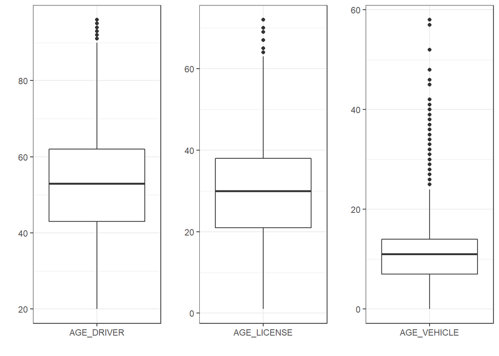

```r
windscreen$INSTALLMENT[windscreen$INSTALLMENT == 9] <- NA

windscreen$GENDER[windscreen$GENDER == 8] <- NA
windscreen$GENDER <- factor(windscreen$GENDER)

windscreen$AGE_DRIVER[windscreen$AGE_DRIVER == 9999] <- NA

windscreen$AGE_ADD_DRIVER[windscreen$AGE_ADD_DRIVER == 9999] <- 0

windscreen$AGE_LICENSE[windscreen$AGE_LICENSE == 9999] <- NA

windscreen$AGE_VEHICLE[windscreen$AGE_VEHICLE == 9999] <- NA

bpa1 <- ggplot(windscreen) + aes(x = 'AGE_DRIVER', y = AGE_DRIVER) + geom_boxplot() + labs (x='', y='')
bpa2 <- ggplot(windscreen) + aes(x = 'AGE_LICENSE', y = AGE_LICENSE) + geom_boxplot() + labs (x='', y='')
bpa3 <- ggplot(windscreen) + aes(x = 'AGE_VEHICLE', y = AGE_VEHICLE) + geom_boxplot() + labs (x='', y='')
grid.arrange(bpa1, bpa2, bpa3, ncol = 3)
```

```r
windscreen$CITIES[windscreen$CITIES == 99] <- NA
windscreen$CITIES <- factor(windscreen$CITIES)

windscreen$HPOWER <- factor(windscreen$HPOWER)

windscreen$VALUE_VEHICLE[windscreen$VALUE_VEHICLE > 4e5] <- NA

windscreen$POSTCODE[windscreen$POSTCODE == 99999] <- NA
windscreen$POSTCODE <- factor(windscreen$POSTCODE)

windscreen$pesopot[windscreen$pesopot == 999] <- NA

windscreen$DES_ZONE2[windscreen$DES_ZONE2 == ''] <- NA

colSums(is.na(windscreen))
```

```
##           YEAR EARNED_PREMIUM    INSTALLMENT         GENDER     AGE_DRIVER
##              0              0              2             51             55
##    AGE_LICENSE AGE_ADD_DRIVER    AGE_VEHICLE         CITIES     BRAND_TEXT
##             51              0             14              5              0
##         HPOWER           FUEL  VALUE_VEHICLE       POSTCODE       N_CLAIMS
##              0              0              1              1              0
##    INCURR_COST       EXPOSURE         ANTPOL        pesopot      DES_ZONE2
##              0              0              0              2            504
##       DES_ZONE          FUEL2
##              0              0
```

Estudiaremos la dependencia de las variables a predecir (ver más adelante), que son `INCURR_COST` y `N_CLAIMS`, con las variables categóricas que mayor número de categorías tienen: `BRAND_TEXT`, `CITIES` (no utilizaremos `POSTCODE` por ser demasiado específica). Agrupamos y pintamos:

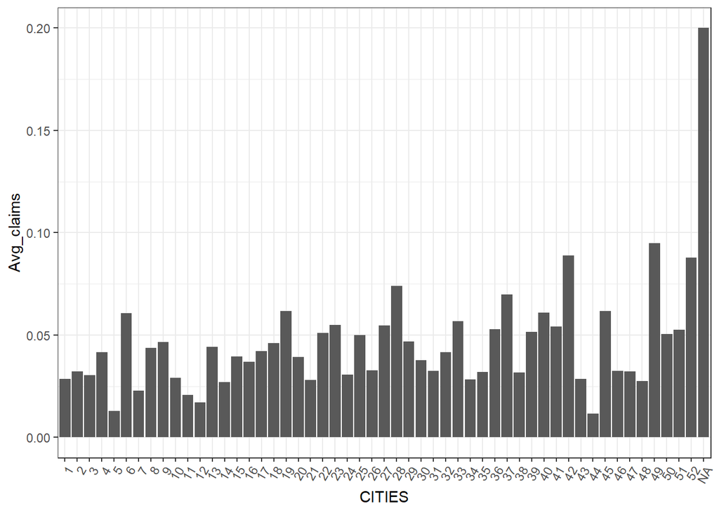

```r
gr.claims.cit <- windscreen[, .(Avg_claims = mean(N_CLAIMS, na.rm = T)), by = CITIES]
gr.claims.brand <- windscreen[, .(Avg_claims = mean(N_CLAIMS, na.rm = T)), by = BRAND_TEXT]
ggplot(gr.claims.cit) + aes(x = CITIES, y = Avg_claims) + geom_bar(stat = 'Identity') +
  theme(axis.text.x = element_text(angle = 60, hjust = 1))
```

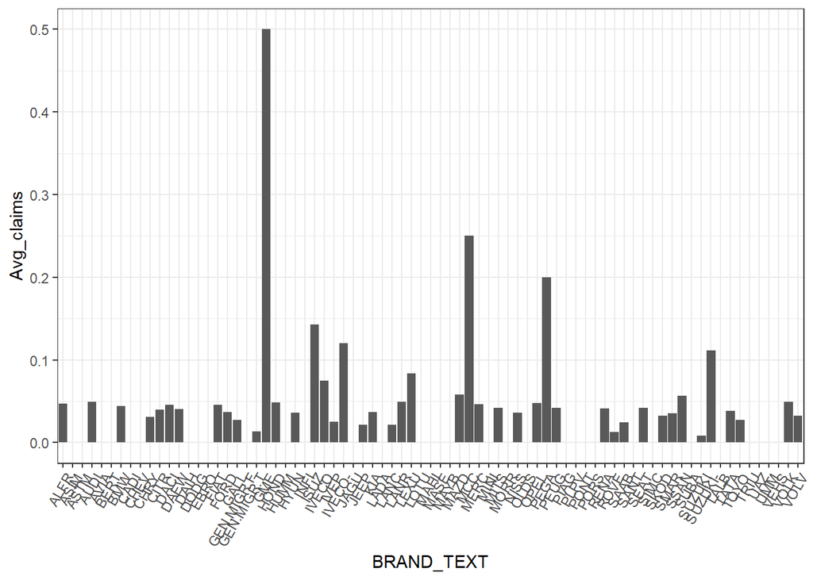

```r
ggplot(gr.claims.brand) + aes(x = BRAND_TEXT, y = Avg_claims) + geom_bar(stat = 'Identity') +
  scale_x_discrete(labels = abbreviate) + theme(axis.text.x = element_text(angle = 60, hjust = 1))
```

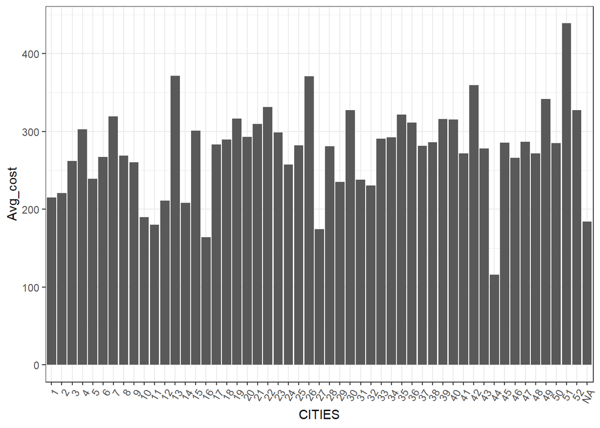

```r
gr.cost.cit <- windscreen[N_CLAIMS != 0 , .(Avg_cost = mean(INCURR_COST/N_CLAIMS, na.rm = T)),
                          by = CITIES]
gr.cost.brand <- windscreen[N_CLAIMS != 0, .(Avg_cost = mean(INCURR_COST/N_CLAIMS, na.rm = T)),
                            by = BRAND_TEXT]
ggplot(gr.cost.cit) + aes(x = CITIES, y = Avg_cost) + geom_bar(stat = 'Identity') +
  theme(axis.text.x = element_text(angle = 60, hjust = 1))
```

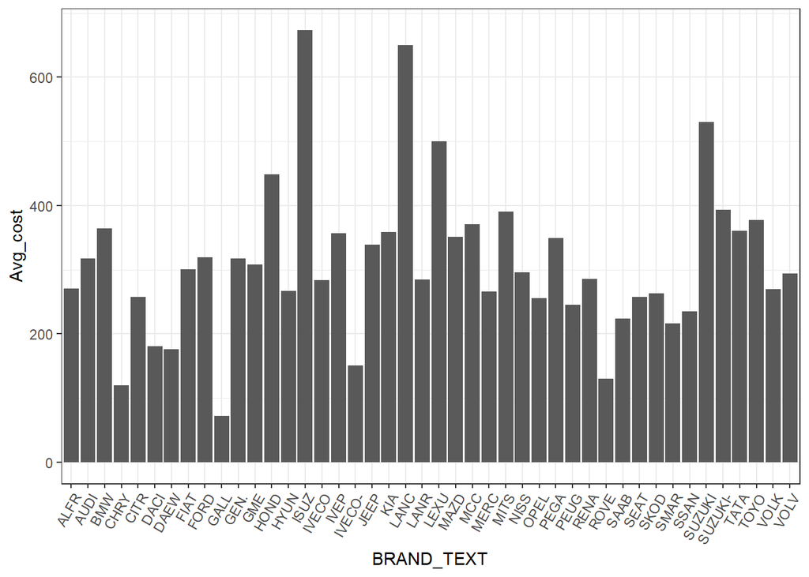

```r
ggplot(gr.cost.brand) + aes(x = BRAND_TEXT, y = Avg_cost) + geom_bar(stat = 'Identity') + scale_x_discrete(labels = abbreviate) + theme(axis.text.x = element_text(angle = 60, hjust = 1))
```

Lo único reseñable de los anteriores gráficos es que el número de siniestros promedio es especialmente alto para las marcas `'GME', 'ISUZU', 'IVECO PEGASO', 'MCC', 'PEGASO', 'SUZUKI-SANTANA'`, construimos una variable binaria que discrimine si el vehículo pertenece a estas marcas. Respecto a `CITIES` no vemos diferencias importantes en estas variables objetivo, así que no la utilizaremos en el análisis.

```r
windscreen$SPECIAL_BRAND <- windscreen$BRAND_TEXT %in% c('GME', 'ISUZU',  'IVECO-PEGASO', 'MCC', 'PEGASO', 'SUZUKI-SANTANA')
# windscreen$SPECIAL_BRAND <- windscreen$BRAND_TEXT %in% c('GME', 'MCC', 'PEGASO', 'SUZUKI-SANTANA')
```

Correlaciones entre variables numéricas:

```r
cor(windscreen[,c(3, 5:8, 13, 15:19)], use="pairwise.complete.obs")
```

```
##                INSTALLMENT   AGE_DRIVER AGE_LICENSE AGE_ADD_DRIVER
## INSTALLMENT     1.00000000 -0.174748774 -0.20760056    0.028264557
## AGE_DRIVER     -0.17474877  1.000000000  0.83969914    0.175539185
## AGE_LICENSE    -0.20760056  0.839699140  1.00000000    0.183495744
## AGE_ADD_DRIVER  0.02826456  0.175539185  0.18349574    1.000000000
## AGE_VEHICLE    -0.04234372  0.173154101  0.14154190    0.097745764
## VALUE_VEHICLE   0.06102712 -0.031103857  0.03616452   -0.020749484
## N_CLAIMS        0.03429043 -0.031979329 -0.03103693   -0.011697619
## INCURR_COST     0.02854280 -0.032338867 -0.03000113   -0.012408696
## EXPOSURE       -0.08115783  0.093234871  0.10368766    0.046467933
## ANTPOL         -0.06430411  0.329738221  0.33220450    0.180524432
## pesopot        -0.01967461 -0.004897852 -0.01056059   -0.001968036
##                AGE_VEHICLE VALUE_VEHICLE    N_CLAIMS INCURR_COST
## INSTALLMENT    -0.04234372    0.06102712  0.03429043  0.02854280
## AGE_DRIVER      0.17315410   -0.03110386 -0.03197933 -0.03233887
## AGE_LICENSE     0.14154190    0.03616452 -0.03103693 -0.03000113
## AGE_ADD_DRIVER  0.09774576   -0.02074948 -0.01169762 -0.01240870
## AGE_VEHICLE     1.00000000   -0.24931710 -0.01531343 -0.01901362
## VALUE_VEHICLE  -0.24931710    1.00000000  0.01679411  0.02740904
## N_CLAIMS       -0.01531343    0.01679411  1.00000000  0.86661548
## INCURR_COST    -0.01901362    0.02740904  0.86661548  1.00000000
## EXPOSURE       -0.01833421   -0.02181092  0.04708036  0.03876394
## ANTPOL          0.18420095   -0.07865253 -0.04299887 -0.03470276
## pesopot         0.09006542   -0.28308346  0.01373124  0.01174849
##                     EXPOSURE      ANTPOL       pesopot
## INSTALLMENT    -0.0811578276 -0.06430411 -0.0196746118
## AGE_DRIVER      0.0932348709  0.32973822 -0.0048978521
## AGE_LICENSE     0.1036876608  0.33220450 -0.0105605941
## AGE_ADD_DRIVER  0.0464679330  0.18052443 -0.0019680364
## AGE_VEHICLE    -0.0183342088  0.18420095  0.0900654196
## VALUE_VEHICLE  -0.0218109236 -0.07865253 -0.2830834614
## N_CLAIMS        0.0470803579 -0.04299887  0.0137312403
## INCURR_COST     0.0387639424 -0.03470276  0.0117484910
## EXPOSURE        1.0000000000  0.07224377 -0.0004830096
## ANTPOL          0.0722437747  1.00000000 -0.0226913312
## pesopot        -0.0004830096 -0.02269133  1.0000000000
```

La edad del conductor y el tiempo de licencia están fuertemente correlacionados (posiblemente solo sea necesario incluir una variable en el análisis). Los costes incurridos y el número de reclamaciones están también relacionadas, evidentemente. Por lo demás no hay correlaciones entre las variables predictoras.

2. Determina la *prima pura conservadora* desde el punto de vista de la aseguradora.

La forma más conservadora de establecer la prima pura para el año entrante sería simplemente establecer la misma para todos los clientes e igual al gasto medio por póliza:

```r
prima_pura_conservadora <- sum(windscreen$INCURR_COST)/nrow(windscreen)
prima_pura_conservadora
```

```
## [1] 11.40881
```

Esta definición implica que los clientes actuales de la aseguradora asumirán el total de los gastos incurridos.

Otra opción supone pesar las pólizas por su exposición, suponiendo que cada póliza no vale lo mismo, y definir:

```r
prima_pura_conservadora_exposicion <- sum(windscreen$INCURR_COST)/sum(windscreen$EXPOSURE)
```

Esta definición es mucho más conservadora (es mayor) pero utilizaremos la primera porque es más sencilla e interpretable.

3. Ajusta (y optimiza) algún modelo más sofisticado para determinar la prima pura más justa para cada asegurado, y compara su rendimiento con el que ofrecería esa *prima pura conservadora* (es decir, determina, de la forma que consideres oportuna, si el modelo que has ajustado es más justo que el más conservador)

El coste de cada poliza se puede predecir mediante:

Coste = Número de siniestros $\times$ Coste medio por siniestro

- El número de siniestros se modela mediante un modelo lineal generalizado de tipo Poisson. En nuestro caso, la variable a predecir es `N_CLAIMS`.
- El coste medio por siniestro (`INCURR_COST/N_CLAIMS`) se modela mediante un GLM de tipo Gamma.
- La credibilidad que se otorga a cada una de las observaciones se pondera en base a su exposición (la fracción del año que ha transcurrido desde que fue contratada la póliza) (`EXPOSURE`).

El primer punto supone predecir si el individuo en particular sufrirá un accidente, y además, el número de ellos. En este tipo de muestras donde el número de ocurrencias es muy bajo (solo hay un 3.9% de `N_CLAIMS > 0`), existen varias maneras de equilibrar el dataset para que los modelos perciban que existen más casos que el trivial, en el que nadie tiene accidentes. Entre las estrategias a seguir se pueden utilizar dos que son complementarias: el denominado *undersampling*, que supone crear una sub-muestra de entrenamiento en la cual la clase mayoritaria (en nuestro caso `N_CLAIMS = 0`) se inframuestrea, reduciéndose su tamaño a uno similar al de la clase minoritaria (`N_CLAIMS > 0`) que suele ser la de interés La alternativa es el *oversampling*, que supone repetir la sub-muestra que integra la clase minoritaria hasta alcanzar un tamaño comparable al de la mayoritaria. Como esta última estrategia puede inducir a *overfitting* optaremos por la primera.

Un problema derivado de estas estrategias es cuándo y dónde introducir el proceso de selección de predictores (*feature selection*): ¿discriminar predictores significativos en la muestra completa, que está desequilibrada?, ¿hacerlo en muestras equilibradas mediante el proceso de *under/over sampling*, donde los predictores podrían cobrar una significación artificial?, ¿probar en submuestras de diferente grado de balanceo?, etc. Un proceso refinado que busca tanto significación como poder predictivo, consiste en seleccionar varias combinaciones de predictores y validar todas y cada una de ellas, por ejemplo mediante *cross validation*, de manera que al final se pueda elegir el conjunto de *features* que presenta un menor error y mayor capacidad predictiva (véase por ejemplo: http://www.marcoaltini.com/blog/dealing-with-imbalanced-data-undersampling-oversampling-and-proper-cross-validation)

Aquí se han probado un modelo con todos los predictores y se ha buscado una combinación reducida de *features* según significancia en sub-muestras *under-sampleadas* de diferente tamaño, empezando en una submuestra que está perfectamente equilibrada (ambas clases del mismo tamaño) hasta llegar a la muestra original, desequilibrada.

```r
set.seed(43)
rows_claimed <- sum(windscreen$N_CLAIMS > 0)

data_claimed <- windscreen[windscreen$N_CLAIMS > 0, ] # Clase minoritaria
data_unclaimed <- windscreen[windscreen$N_CLAIMS == 0, ] # Clase mayoritaria

# Balanceo en diferentes grados: tamaño de N_CLAIMS == 0 en la submuestra: n= 1, 4 y 20 veces el tamaño de N_CLAIMS > 0 hasta la muestra original (full).
# Regresiones
size.unc = 1 # 1, 4, 20
indices <- sample(nrow(data_unclaimed), size.unc*rows_claimed) # Training
training_data_unclaimed <- data_unclaimed[indices, ]
training_data <- rbind(data_claimed, training_data_unclaimed)

model.first <- glm(N_CLAIMS ~ INSTALLMENT + GENDER + AGE_DRIVER +
                           AGE_ADD_DRIVER + AGE_VEHICLE + HPOWER + FUEL2 +
                           VALUE_VEHICLE + ANTPOL + pesopot + DES_ZONE2 +
                           SPECIAL_BRAND,
                        data = training_data,
                        family = poisson(link = 'log'),
                        weights = EXPOSURE) # First model
summary(model.first)
```

```
##
## Call:
## glm(formula = N_CLAIMS ~ INSTALLMENT + GENDER + AGE_DRIVER +
##     AGE_ADD_DRIVER + AGE_VEHICLE + HPOWER + FUEL2 + VALUE_VEHICLE +
##     ANTPOL + pesopot + DES_ZONE2 + SPECIAL_BRAND, family = poisson(link = "log"),
##     data = training_data, weights = EXPOSURE)
##
## Deviance Residuals:
##      Min        1Q    Median        3Q       Max
## -1.29940  -0.92987  -0.09219   0.48219   2.04597
##
## Coefficients:
##                     Estimate Std. Error z value Pr(>|z|)
## (Intercept)       -9.861e-01  1.100e+00  -0.896  0.37016
## INSTALLMENT        1.241e-01  6.972e-02   1.780  0.07507 .
## GENDER2           -9.215e-02  9.347e-02  -0.986  0.32419
## AGE_DRIVER        -6.134e-03  2.966e-03  -2.068  0.03865 *
## AGE_ADD_DRIVER    -9.020e-04  2.052e-03  -0.440  0.66022
## AGE_VEHICLE        6.752e-03  7.988e-03   0.845  0.39795
## HPOWER2            1.435e-01  1.160e+00   0.124  0.90156
## HPOWER3            2.995e-01  1.170e+00   0.256  0.79792
## HPOWER4            5.740e-01  1.052e+00   0.546  0.58529
## HPOWER5            6.055e-01  1.052e+00   0.576  0.56475
## HPOWER6            7.608e-01  1.056e+00   0.720  0.47148
## HPOWER7            7.071e-01  1.056e+00   0.670  0.50296
## HPOWER8            7.733e-01  1.062e+00   0.728  0.46651
## HPOWER9            8.576e-01  1.068e+00   0.803  0.42181
## HPOWER10           9.063e-01  1.088e+00   0.833  0.40480
## HPOWER11           7.663e-01  1.108e+00   0.692  0.48908
## HPOWER12           8.555e-01  1.164e+00   0.735  0.46252
## HPOWER13           9.835e-01  1.179e+00   0.834  0.40401
## FUEL2G            -2.533e-01  9.102e-02  -2.783  0.00538 **
## VALUE_VEHICLE     -5.826e-06  9.385e-06  -0.621  0.53476
## ANTPOL            -1.675e-02  8.422e-03  -1.989  0.04672 *
## pesopot            4.636e-03  1.357e-02   0.342  0.73267
## DES_ZONE2SubUrb   -4.128e-02  8.722e-02  -0.473  0.63605
## DES_ZONE2Urbano    3.958e-02  8.934e-02   0.443  0.65779
## DES_ZONE2añadido  -7.500e-01  1.009e+00  -0.743  0.45721
## SPECIAL_BRANDTRUE  5.117e-01  4.117e-01   1.243  0.21392
## ---
## Signif. codes:  0 '***' 0.001 '**' 0.01 '*' 0.05 '.' 0.1 ' ' 1
##
## (Dispersion parameter for poisson family taken to be 1)
##
##     Null deviance: 1123.7  on 1896  degrees of freedom
## Residual deviance: 1079.9  on 1871  degrees of freedom
##   (45 observations deleted due to missingness)
## AIC: 2788.7
##
## Number of Fisher Scoring iterations: 5
```

```r
model.red.1 <- glm(N_CLAIMS ~ INSTALLMENT + AGE_DRIVER + FUEL2 + ANTPOL,
                      data = training_data,
                      family = poisson(link = 'log'),
                      weights = EXPOSURE) # Modero reducido para size.unc = 1
summary(model.red.1)
```

```
##
## Call:
## glm(formula = N_CLAIMS ~ INSTALLMENT + AGE_DRIVER + FUEL2 + ANTPOL,
##     family = poisson(link = "log"), data = training_data, weights = EXPOSURE)
##
## Deviance Residuals:
##      Min        1Q    Median        3Q       Max
## -1.29114  -0.94390  -0.09028   0.48598   2.07701
##
## Coefficients:
##              Estimate Std. Error z value Pr(>|z|)
## (Intercept) -0.277777   0.182320  -1.524 0.127618
## INSTALLMENT  0.125531   0.068128   1.843 0.065392 .
## AGE_DRIVER  -0.006050   0.002802  -2.159 0.030817 *
## FUEL2G      -0.247182   0.074386  -3.323 0.000891 ***
## ANTPOL      -0.016230   0.008126  -1.997 0.045794 *
## ---
## Signif. codes:  0 '***' 0.001 '**' 0.01 '*' 0.05 '.' 0.1 ' ' 1
##
## (Dispersion parameter for poisson family taken to be 1)
##
##     Null deviance: 1149.2  on 1938  degrees of freedom
## Residual deviance: 1116.1  on 1934  degrees of freedom
##   (3 observations deleted due to missingness)
## AIC: 2819.9
##
## Number of Fisher Scoring iterations: 5
```

```r
size.unc = 4 # 1, 4, 20
indices <- sample(nrow(data_unclaimed), size.unc*rows_claimed) # Training
training_data_unclaimed <- data_unclaimed[indices, ]
training_data <- rbind(data_claimed, training_data_unclaimed)

model.red.4 <- glm(N_CLAIMS ~ INSTALLMENT + GENDER + AGE_DRIVER +
                      FUEL2 + ANTPOL + SPECIAL_BRAND,
                      data = training_data,
                      family = poisson(link = 'log'),
                      weights = EXPOSURE) # Modero reducido para size.unc = 4
summary(model.red.4)
```

```
##
## Call:
## glm(formula = N_CLAIMS ~ INSTALLMENT + GENDER + AGE_DRIVER +
##     FUEL2 + ANTPOL + SPECIAL_BRAND, family = poisson(link = "log"),
##     data = training_data, weights = EXPOSURE)
##
## Deviance Residuals:
##     Min       1Q   Median       3Q      Max
## -1.1827  -0.6555  -0.5381  -0.2437   2.8365
##
## Coefficients:
##                    Estimate Std. Error z value Pr(>|z|)
## (Intercept)       -1.127878   0.186146  -6.059 1.37e-09 ***
## INSTALLMENT        0.266538   0.067828   3.930 8.51e-05 ***
## GENDER2           -0.196073   0.090164  -2.175   0.0297 *
## AGE_DRIVER        -0.006929   0.002863  -2.420   0.0155 *
## FUEL2G            -0.299004   0.075034  -3.985 6.75e-05 ***
## ANTPOL            -0.036485   0.008060  -4.526 6.00e-06 ***
## SPECIAL_BRANDTRUE  0.567406   0.399869   1.419   0.1559
## ---
## Signif. codes:  0 '***' 0.001 '**' 0.01 '*' 0.05 '.' 0.1 ' ' 1
##
## (Dispersion parameter for poisson family taken to be 1)
##
##     Null deviance: 2704.7  on 4843  degrees of freedom
## Residual deviance: 2617.5  on 4837  degrees of freedom
##   (11 observations deleted due to missingness)
## AIC: 4325.3
##
## Number of Fisher Scoring iterations: 6
```

```r
size.unc = 20 # 1, 4, 20
indices <- sample(nrow(data_unclaimed), size.unc*rows_claimed) # Training
training_data_unclaimed <- data_unclaimed[indices, ]
training_data <- rbind(data_claimed, training_data_unclaimed)

model.red.20 <- glm(N_CLAIMS ~ INSTALLMENT + GENDER + AGE_DRIVER +
                      FUEL2 + ANTPOL + SPECIAL_BRAND,
                      data = training_data,
                      family = poisson(link = 'log'),
                      weights = EXPOSURE) # Modero reducido para size.unc = 20
summary(model.red.20)
```

```
##
## Call:
## glm(formula = N_CLAIMS ~ INSTALLMENT + GENDER + AGE_DRIVER +
##     FUEL2 + ANTPOL + SPECIAL_BRAND, family = poisson(link = "log"),
##     data = training_data, weights = EXPOSURE)
##
## Deviance Residuals:
##     Min       1Q   Median       3Q      Max
## -0.8164  -0.3374  -0.2817  -0.2138   3.9642
##
## Coefficients:
##                    Estimate Std. Error z value Pr(>|z|)
## (Intercept)       -2.477574   0.186444 -13.289  < 2e-16 ***
## INSTALLMENT        0.284946   0.068178   4.179 2.92e-05 ***
## GENDER2           -0.232198   0.090163  -2.575  0.01001 *
## AGE_DRIVER        -0.007421   0.002888  -2.570  0.01017 *
## FUEL2G            -0.357242   0.074876  -4.771 1.83e-06 ***
## ANTPOL            -0.042573   0.008190  -5.198 2.01e-07 ***
## SPECIAL_BRANDTRUE  1.190953   0.399569   2.981  0.00288 **
## ---
## Signif. codes:  0 '***' 0.001 '**' 0.01 '*' 0.05 '.' 0.1 ' ' 1
##
## (Dispersion parameter for poisson family taken to be 1)
##
##     Null deviance: 5178.9  on 20339  degrees of freedom
## Residual deviance: 5061.8  on 20333  degrees of freedom
##   (51 observations deleted due to missingness)
## AIC: 6769.6
##
## Number of Fisher Scoring iterations: 6
```

```r
model.red.full <- glm(N_CLAIMS ~ INSTALLMENT + GENDER + AGE_DRIVER +
                      FUEL2 + ANTPOL + SPECIAL_BRAND,
                      data = windscreen,
                      family = poisson(link = 'log'),
                      weights = EXPOSURE) # Full sample
summary(model.red.full)
```

```
##
## Call:
## glm(formula = N_CLAIMS ~ INSTALLMENT + GENDER + AGE_DRIVER +
##     FUEL2 + ANTPOL + SPECIAL_BRAND, family = poisson(link = "log"),
##     data = windscreen, weights = EXPOSURE)
##
## Deviance Residuals:
##     Min       1Q   Median       3Q      Max
## -0.7625  -0.3060  -0.2556  -0.1956   4.1081
##
## Coefficients:
##                    Estimate Std. Error z value Pr(>|z|)
## (Intercept)       -2.678595   0.185941 -14.406  < 2e-16 ***
## INSTALLMENT        0.293914   0.068128   4.314 1.60e-05 ***
## GENDER2           -0.238072   0.090146  -2.641  0.00827 **
## AGE_DRIVER        -0.007713   0.002890  -2.669  0.00762 **
## FUEL2G            -0.355349   0.074918  -4.743 2.10e-06 ***
## ANTPOL            -0.041558   0.008198  -5.069 3.99e-07 ***
## SPECIAL_BRANDTRUE  1.233204   0.399473   3.087  0.00202 **
## ---
## Signif. codes:  0 '***' 0.001 '**' 0.01 '*' 0.05 '.' 0.1 ' ' 1
##
## (Dispersion parameter for poisson family taken to be 1)
##
##     Null deviance: 5528.0  on 24859  degrees of freedom
## Residual deviance: 5409.8  on 24853  degrees of freedom
##   (59 observations deleted due to missingness)
## AIC: 7117.6
##
## Number of Fisher Scoring iterations: 6
```

Nótese que hemos utilizado `EXPOSURE` como peso de las observaciones.

Los modelos reducidos significativos para tamaño relativo 1:4, 1:20 entre clases `N_CLAIMS = 0`:`N_CLAIMS > 0` y el reducido de muestra completa tienen la misma formulación, comparten el mismo set de predictores. Curiosamente podríamos habernos ahorrado estudiar submuestras equilibradas y haber optado por buscar un modelo en el set de datos original.

Hasta aquí, el número de siniestros:

- crece con el número de plazos que tiene suscrito el conductor en el pago de la prima (!) (¿este fraccionamiento del pago se relaciona con la situación económica? ¿y esta última con la salud del vehículo?);
- disminuye si es `GENDER = 2` (presumiblemente mujer, no está claro de la info que tenemos previa del dataset)
- depende inversamente de la edad del conductor;
- es menor para vehículos propulsados por gasolina;
- es menor a mayor antigüedad de la poliza;
- es mayor en el subconjunto de marcas seleccionadas.

Esto respecto al número de reclamaciones, mientras que para `INCURR_COST/N_CLAIMS` seguimos el siguiente procedimiento (previa construcción de la variable coste por siniestro):

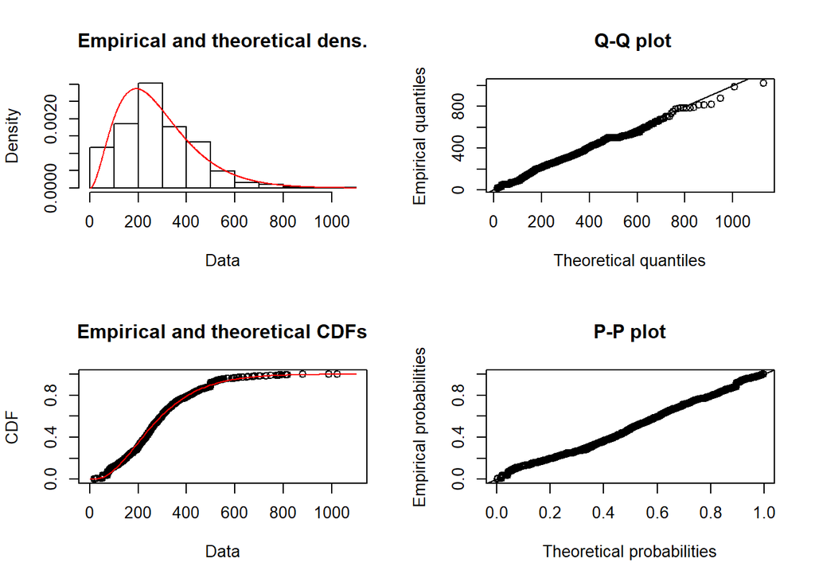

```r
windscreen$CLAIM_COST <- windscreen$INCURR_COST / windscreen$N_CLAIMS
windscreen$CLAIM_COST[is.nan(windscreen$CLAIM_COST)] <- 0

plot(fitdist(windscreen$CLAIM_COST[windscreen$CLAIM_COST>0], 'gamma'))
```

```r
model.claimcost.full <- glm(CLAIM_COST ~ INSTALLMENT + GENDER + AGE_DRIVER +
                           AGE_ADD_DRIVER + AGE_VEHICLE + HPOWER + FUEL2 +
                           VALUE_VEHICLE + ANTPOL + pesopot + DES_ZONE2 +
                           SPECIAL_BRAND,
                        data = windscreen[windscreen$CLAIM_COST>0],
                        family = Gamma(link = 'log'),
                        weights = EXPOSURE)
summary(model.claimcost.full)
```

```
##
## Call:
## glm(formula = CLAIM_COST ~ INSTALLMENT + GENDER + AGE_DRIVER +
##     AGE_ADD_DRIVER + AGE_VEHICLE + HPOWER + FUEL2 + VALUE_VEHICLE +
##     ANTPOL + pesopot + DES_ZONE2 + SPECIAL_BRAND, family = Gamma(link = "log"),
##     data = windscreen[windscreen$CLAIM_COST > 0], weights = EXPOSURE)
##
## Deviance Residuals:
##      Min        1Q    Median        3Q       Max
## -1.91733  -0.35723  -0.04793   0.23414   1.33166
##
## Coefficients:
##                     Estimate Std. Error t value Pr(>|t|)
## (Intercept)        5.881e+00  5.281e-01  11.136  < 2e-16 ***
## INSTALLMENT       -2.943e-03  3.541e-02  -0.083 0.933786
## GENDER2            3.221e-02  4.723e-02   0.682 0.495464
## AGE_DRIVER        -1.548e-03  1.462e-03  -1.059 0.289826
## AGE_ADD_DRIVER     1.529e-04  1.060e-03   0.144 0.885314
## AGE_VEHICLE       -5.834e-03  4.017e-03  -1.452 0.146717
## HPOWER2           -6.306e-01  5.750e-01  -1.097 0.273024
## HPOWER3           -4.206e-01  5.748e-01  -0.732 0.464499
## HPOWER4           -6.407e-01  5.175e-01  -1.238 0.215955
## HPOWER5           -4.599e-01  5.159e-01  -0.891 0.372940
## HPOWER6           -3.534e-01  5.189e-01  -0.681 0.496031
## HPOWER7           -3.424e-01  5.153e-01  -0.665 0.506503
## HPOWER8           -9.792e-02  5.163e-01  -0.190 0.849633
## HPOWER9           -1.791e-01  5.191e-01  -0.345 0.730167
## HPOWER10           7.464e-03  5.284e-01   0.014 0.988734
## HPOWER11          -1.255e-01  5.330e-01  -0.235 0.813975
## HPOWER12           4.069e-01  5.610e-01   0.725 0.468469
## HPOWER13           5.431e-01  5.684e-01   0.955 0.339606
## FUEL2G             1.349e-02  4.651e-02   0.290 0.771895
## VALUE_VEHICLE     -7.424e-06  4.873e-06  -1.524 0.127960
## ANTPOL             5.839e-03  4.081e-03   1.431 0.152858
## pesopot            2.688e-02  7.422e-03   3.621 0.000310 ***
## DES_ZONE2SubUrb   -2.295e-01  4.380e-02  -5.241 1.98e-07 ***
## DES_ZONE2Urbano   -1.535e-01  4.505e-02  -3.407 0.000686 ***
## DES_ZONE2añadido  -5.079e-01  5.049e-01  -1.006 0.314690
## SPECIAL_BRANDTRUE  1.741e-01  2.024e-01   0.860 0.389889
## ---
## Signif. codes:  0 '***' 0.001 '**' 0.01 '*' 0.05 '.' 0.1 ' ' 1
##
## (Dispersion parameter for Gamma family taken to be 0.2353007)
##
##     Null deviance: 279.26  on 940  degrees of freedom
## Residual deviance: 254.40  on 915  degrees of freedom
##   (23 observations deleted due to missingness)
## AIC: 10344
##
## Number of Fisher Scoring iterations: 6
```

```r
model.claimcost.two <- glm(CLAIM_COST ~ AGE_DRIVER + AGE_VEHICLE +
                           VALUE_VEHICLE + DES_ZONE2,
                        data = windscreen[windscreen$CLAIM_COST>0],
                        family = Gamma(link = 'log'),
                        weights = EXPOSURE)
summary(model.claimcost.two)
```

```
##
## Call:
## glm(formula = CLAIM_COST ~ AGE_DRIVER + AGE_VEHICLE + VALUE_VEHICLE +
##     DES_ZONE2, family = Gamma(link = "log"), data = windscreen[windscreen$CLAIM_COST >
##     0], weights = EXPOSURE)
##
## Deviance Residuals:
##      Min        1Q    Median        3Q       Max
## -1.95874  -0.36349  -0.06469   0.24678   1.30478
##
## Coefficients:
##                    Estimate Std. Error t value Pr(>|t|)
## (Intercept)       5.644e+00  9.332e-02  60.479  < 2e-16 ***
## AGE_DRIVER       -1.536e-03  1.375e-03  -1.117 0.264331
## AGE_VEHICLE      -4.150e-03  3.867e-03  -1.073 0.283494
## VALUE_VEHICLE     1.043e-05  2.284e-06   4.565 5.66e-06 ***
## DES_ZONE2SubUrb  -2.286e-01  4.360e-02  -5.243 1.95e-07 ***
## DES_ZONE2Urbano  -1.514e-01  4.467e-02  -3.388 0.000733 ***
## DES_ZONE2añadido -6.985e-01  4.948e-01  -1.412 0.158388
## ---
## Signif. codes:  0 '***' 0.001 '**' 0.01 '*' 0.05 '.' 0.1 ' ' 1
##
## (Dispersion parameter for Gamma family taken to be 0.2408574)
##
##     Null deviance: 279.26  on 940  degrees of freedom
## Residual deviance: 265.11  on 934  degrees of freedom
##   (23 observations deleted due to missingness)
## AIC: 10341
##
## Number of Fisher Scoring iterations: 5
```

```r
model.claimcost.three <- glm(CLAIM_COST ~ VALUE_VEHICLE + DES_ZONE2,
                        data = windscreen[windscreen$CLAIM_COST>0],
                        family = Gamma(link = 'log'),
                        weights = EXPOSURE)
summary(model.claimcost.three)
```

```
##
## Call:
## glm(formula = CLAIM_COST ~ VALUE_VEHICLE + DES_ZONE2, family = Gamma(link = "log"),
##     data = windscreen[windscreen$CLAIM_COST > 0], weights = EXPOSURE)
##
## Deviance Residuals:
##      Min        1Q    Median        3Q       Max
## -1.95436  -0.36583  -0.06089   0.25057   1.35574
##
## Coefficients:
##                    Estimate Std. Error t value Pr(>|t|)
## (Intercept)       5.509e+00  4.652e-02 118.424  < 2e-16 ***
## VALUE_VEHICLE     1.115e-05  2.185e-06   5.103 4.05e-07 ***
## DES_ZONE2SubUrb  -2.290e-01  4.350e-02  -5.266 1.73e-07 ***
## DES_ZONE2Urbano  -1.537e-01  4.454e-02  -3.451 0.000584 ***
## DES_ZONE2añadido -7.426e-01  4.916e-01  -1.511 0.131244
## ---
## Signif. codes:  0 '***' 0.001 '**' 0.01 '*' 0.05 '.' 0.1 ' ' 1
##
## (Dispersion parameter for Gamma family taken to be 0.2402937)
##
##     Null deviance: 279.76  on 943  degrees of freedom
## Residual deviance: 266.25  on 939  degrees of freedom
##   (20 observations deleted due to missingness)
## AIC: 10369
##
## Number of Fisher Scoring iterations: 5
```

```r
windscreen$URBAN <- windscreen$DES_ZONE2 %in% c('SubUrb', 'Urbano')

model.claimcost.four <- glm(CLAIM_COST ~ VALUE_VEHICLE + URBAN,
                        data = windscreen[windscreen$CLAIM_COST>0],
                        family = Gamma(link = 'log'),
                        weights = EXPOSURE)
summary(model.claimcost.four)
```

```
##
## Call:
## glm(formula = CLAIM_COST ~ VALUE_VEHICLE + URBAN, family = Gamma(link = "log"),
##     data = windscreen[windscreen$CLAIM_COST > 0], weights = EXPOSURE)
##
## Deviance Residuals:
##      Min        1Q    Median        3Q       Max
## -1.95164  -0.37806  -0.06452   0.25801   1.36469
##
## Coefficients:
##                 Estimate Std. Error t value Pr(>|t|)
## (Intercept)    5.500e+00  4.602e-02 119.510  < 2e-16 ***
## VALUE_VEHICLE  1.126e-05  2.171e-06   5.188 2.59e-07 ***
## URBANTRUE     -1.852e-01  3.480e-02  -5.323 1.27e-07 ***
## ---
## Signif. codes:  0 '***' 0.001 '**' 0.01 '*' 0.05 '.' 0.1 ' ' 1
##
## (Dispersion parameter for Gamma family taken to be 0.2420339)
##
##     Null deviance: 286.67  on 963  degrees of freedom
## Residual deviance: 274.19  on 961  degrees of freedom
## AIC: 10598
##
## Number of Fisher Scoring iterations: 5
```

Este modelo indica que el coste por siniestro aumenta con el valor del vehículo y disminuye si el cliente procede de un entorno urbano. El ajuste del modelo a los datos es bastante razonable:

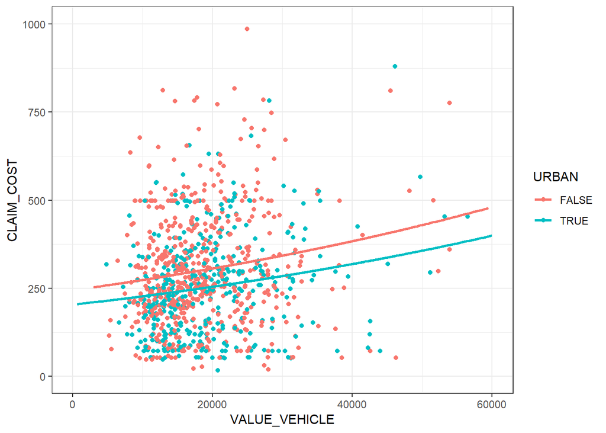

```r
predictions.claimcost <- predict(model.claimcost.four,
                       newdata = windscreen,
                       type = 'response')

windscreen$predictions.claimcst <- predictions.claimcost

ggplot(data = windscreen,
       aes(x = VALUE_VEHICLE, y = CLAIM_COST, col = URBAN)) +
  geom_point() +
  geom_line(aes(y = predictions.claimcost ), size = 1) +
  xlim(1,60000) + ylim(1, 1000)
```

No se han hecho visualizaciones de posibles predicciones de `N_CLAIMS` porque son todos muy cercanos a cero (por debajo de 0.5), esto se debe al hecho ya mencionado de que el dataset está muy despoblado y a que el modelo trata la variable objetivo como continua. Estos valores fraccionarios se pueden interpretar como la probabilidad de que el sujeto en cuestión sufra accidentes, que es mayor a mayor número de accidentes futuribles (8-|). Dado que esta predicción se utilizará como input de un modelo compuesto (coste = n_claims*claimcost), veremos que no supone un problema en la interpretación del coste.

Validamos los modelos parciales y refinamos los coeficientes mediante *10-fold cross validation*:

```r
train_control<- trainControl(method="cv", number=10, savePredictions = TRUE)

model.n_claims <- train(N_CLAIMS ~ INSTALLMENT + GENDER + AGE_DRIVER +
                      FUEL2 + ANTPOL + SPECIAL_BRAND,
                      data = windscreen,
                      trControl = train_control,
                      method = 'glm',
                      family = poisson(link = 'log'),
                      weights = EXPOSURE, na.action = na.omit) # cross validation

model.claimcost <- train(CLAIM_COST ~ VALUE_VEHICLE + URBAN,
                         data = windscreen[windscreen$CLAIM_COST>0],
                         trControl = train_control,
                         method = 'glm',
                         family = Gamma(link = 'log'),
                         weights = EXPOSURE,
                         na.action = na.omit)
```

Para validar más correctamente un método adecuado puede ser *cross-validation* en muestras totalmente equilibradas (http://www.marcoaltini.com/blog/dealing-with-imbalanced-data-undersampling-oversampling-and-proper-cross-validation o https://www.r-bloggers.com/handling-class-imbalance-with-r-and-caret-an-introduction/). Como la validación aquí implementada proporciona resultados razonables (como veremos más adelante) no complicaremos más el procedimiento.

Una vez que tenemos ambos ingredientes predecimos el coste en el que va a incurrir el cliente el año entrante:

```r
predictions.nclaims <- model.n_claims$pred$pred# predecimos aquí N_CLAIMS
predictions.claimcost<- predict(model.claimcost, windscreen,type = "raw") # coste unitario
cost.pred = predictions.nclaims*predictions.claimcost # Coste por cliente
windscreen$cost.pred <- cost.pred
```

Este coste se puede interpretar como la **prima predicha** con la que habrá que gravar a nuestros clientes.

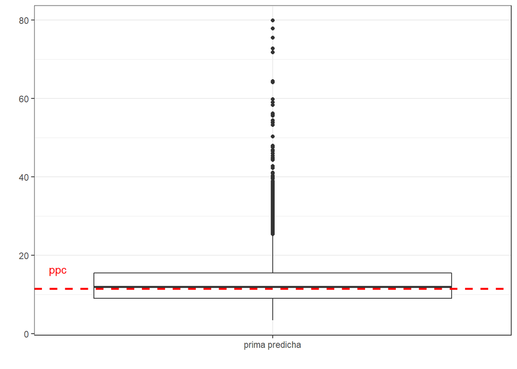

```r
ggplot(windscreen) + aes(x = 'prima predicha', y = cost.pred) + geom_boxplot() + labs(x='', y='') +
geom_hline(aes(yintercept=prima_pura_conservadora),  color="red", linetype="dashed", size=1) +
  annotate("text", 0.55 , prima_pura_conservadora + 5, label = "ppc", colour = 'red')
```

En promedio, la prima predicha, 12.72, es mayor que la prima conservadora, 11.41, es inferior un 45.7% de las veces, y su mediana es 11.95, más parecida a la conservadora. En la gráfica anterior se ve un conjunto de outliers a valores altos. En términos de ingresos totales, con la prima pura se recaudaría un total de 284296 y con la prima estimada 317019, un 11.5% más.

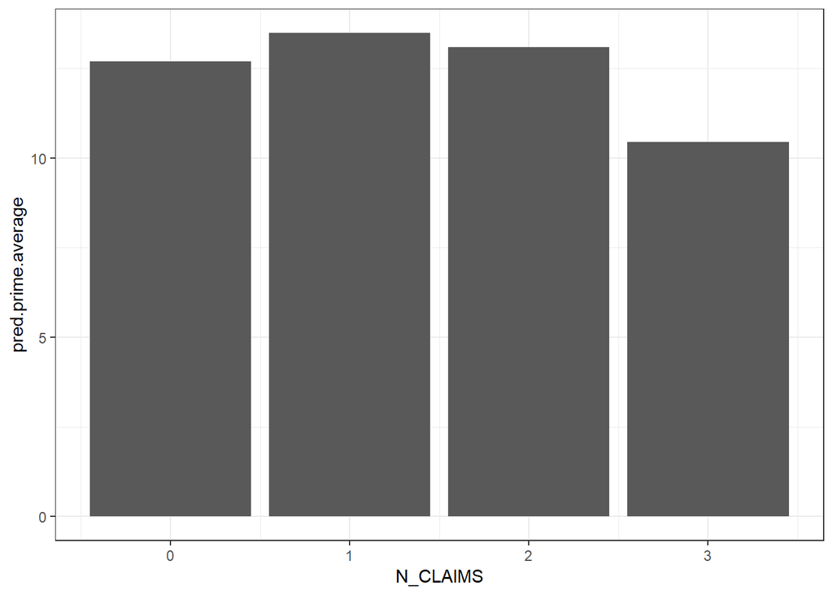

```r
g <- windscreen[, .(pred.prime.average= mean(cost.pred, na.rm = T)) , by = N_CLAIMS]
ggplot(g) +  aes(x = N_CLAIMS, y = pred.prime.average) + geom_bar(stat = 'Identity')
```

En el sentido de que **es mayor, en promedio. para los clientes que sufrieron algún accidente la prima estimada es más justa que la prima conservadora**, la cual es idéntica para todos los clientes. Esto se aprecia también en el siguiente gráfico de densidad (donde se han omitido los outliers y los dos únicos casos de `N_CLAIMS = 3`):

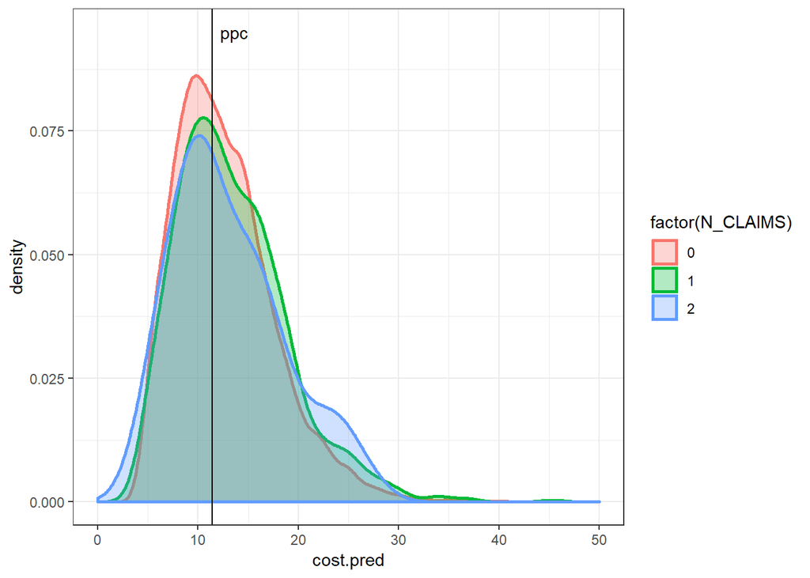

```r
ggplot(subset(windscreen, N_CLAIMS %in% c(0,1,2)), aes(x= cost.pred, colour = factor(N_CLAIMS), fill=factor(N_CLAIMS))) +
  geom_density(size=1, alpha=.3) +
  xlim(0,50) + geom_vline(aes(xintercept=prima_pura_conservadora)) +
  annotate("text", prima_pura_conservadora + 2.2, 0.095 , label = "ppc")
```

4. Interpreta el modelo y confirma o desmiente tus hipótesis del apartado (a).

En general el modelo sobreestima los gastos incurridos y muy probablemente se deba a su formulación o quizá a que sea necesario introducir un procedimiento más refinado de validación (no profundizaremos más en este punto).

Ya se ha dado una interpretación al modelo en el apartado anterior y los predictores son, en orden de importancia (según el valor de los coeficientes y su signo):

- `SPECIAL_BRAND, INSTALLMENT` que influyen positivamente en el número de reclamaciones y,
- `FUEL2`, `GENDER`, `ANTPOL` y `AGE_DRIVER` que disminuyen el número de siniestros, los dos últimos de manera marginal.
- `URBAN` que disminuye el coste y `VALUE_VEHICLE` que parece que tiene una pequeña influencia creciente en los costes.

```r
summary(model.n_claims)
```

```
##
## Call:
## NULL
##
## Deviance Residuals:
##     Min       1Q   Median       3Q      Max
## -0.7625  -0.3060  -0.2556  -0.1956   4.1081
##
## Coefficients:
##                    Estimate Std. Error z value Pr(>|z|)
## (Intercept)       -2.678595   0.185941 -14.406  < 2e-16 ***
## INSTALLMENT        0.293914   0.068128   4.314 1.60e-05 ***
## GENDER2           -0.238072   0.090146  -2.641  0.00827 **
## AGE_DRIVER        -0.007713   0.002890  -2.669  0.00762 **
## FUEL2G            -0.355349   0.074918  -4.743 2.10e-06 ***
## ANTPOL            -0.041558   0.008198  -5.069 3.99e-07 ***
## SPECIAL_BRANDTRUE  1.233204   0.399473   3.087  0.00202 **
## ---
## Signif. codes:  0 '***' 0.001 '**' 0.01 '*' 0.05 '.' 0.1 ' ' 1
##
## (Dispersion parameter for poisson family taken to be 1)
##
##     Null deviance: 5528.0  on 24859  degrees of freedom
## Residual deviance: 5409.8  on 24853  degrees of freedom
## AIC: 7117.6
##
## Number of Fisher Scoring iterations: 6
```

```r
summary(model.claimcost)
```

```
##
## Call:
## NULL
##
## Deviance Residuals:
##      Min        1Q    Median        3Q       Max
## -1.95164  -0.37806  -0.06452   0.25801   1.36469
##
## Coefficients:
##                 Estimate Std. Error t value Pr(>|t|)
## (Intercept)    5.500e+00  4.602e-02 119.510  < 2e-16 ***
## VALUE_VEHICLE  1.126e-05  2.171e-06   5.188 2.59e-07 ***
## URBANTRUE     -1.852e-01  3.480e-02  -5.323 1.27e-07 ***
## ---
## Signif. codes:  0 '***' 0.001 '**' 0.01 '*' 0.05 '.' 0.1 ' ' 1
##
## (Dispersion parameter for Gamma family taken to be 0.2420339)
##
##     Null deviance: 286.67  on 963  degrees of freedom
## Residual deviance: 274.19  on 961  degrees of freedom
## AIC: 10598
##
## Number of Fisher Scoring iterations: 5
```

Solamente se exploró la pertenencia a las marcas especiales en el apartado a) y esto está de acuerdo con el hecho de que sea un predictor significativo para el número de siniestros. Resulta que esas marcas en particular son de vehículos de transporte comercial (camiones, furgonetas, etc) y todo terrenos, por lo que es normal que sufran más accidentes de lunas.